# Practice Midterm

Marleny Tochihuitl-Mendoza

2025-03-03

### Plot and Inference

```r
library(fpp2)
```

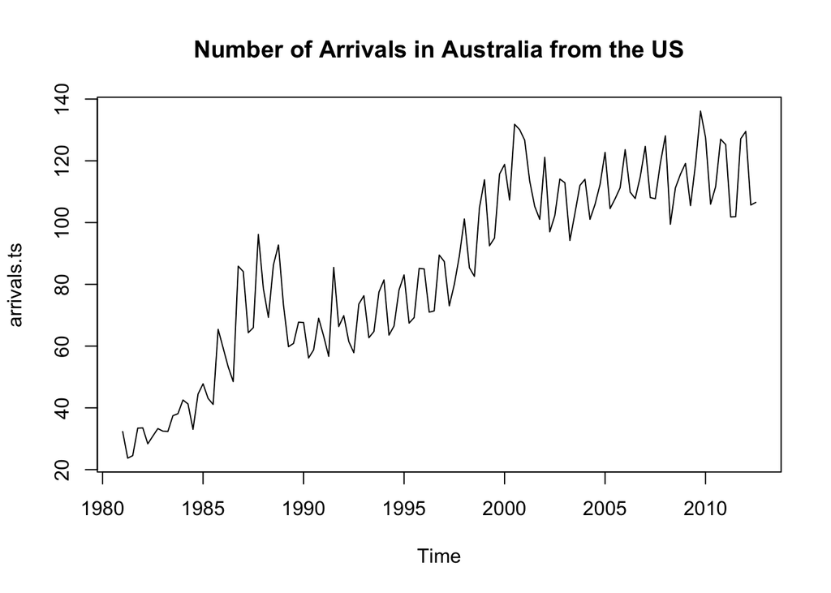

```r
arrivals.ts<-arrivals[,4]
plot(arrivals.ts, main = "Number of Arrivals in Australia from the US")
```

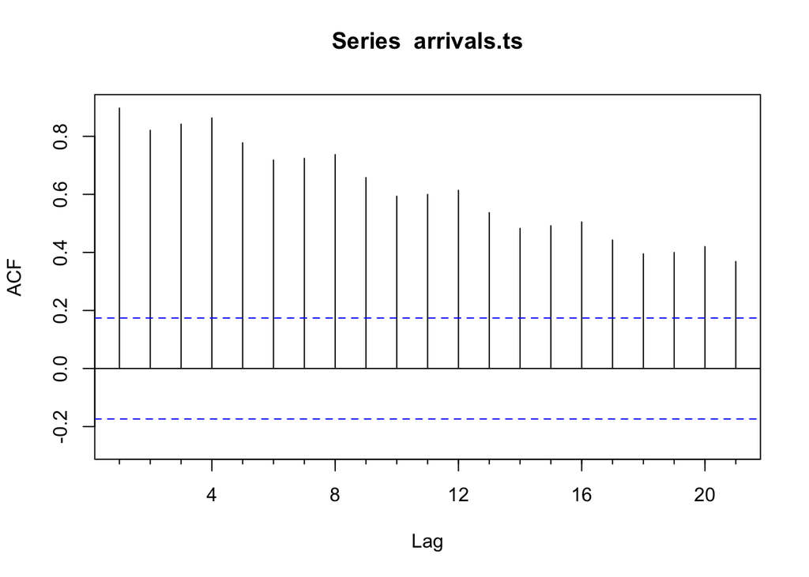

```r
Acf(arrivals.ts)
```

##### The plot has an increasing trend of arrivals in Australia from the United states. There seems to be some peaks at certain time periods signifying potential seasonality. In the Acf there appears to be seasonality at each quarter 4. All lags are significant signifying that past data influences the present data given the strong correlation, however, as more time passes, the significance slowly decliens.

### Central Tendency

```r
summary(arrivals.ts)
```

```
##    Min. 1st Qu.  Median    Mean 3rd Qu.    Max.
##   23.72   63.95   85.88   84.85  108.98  136.09
```

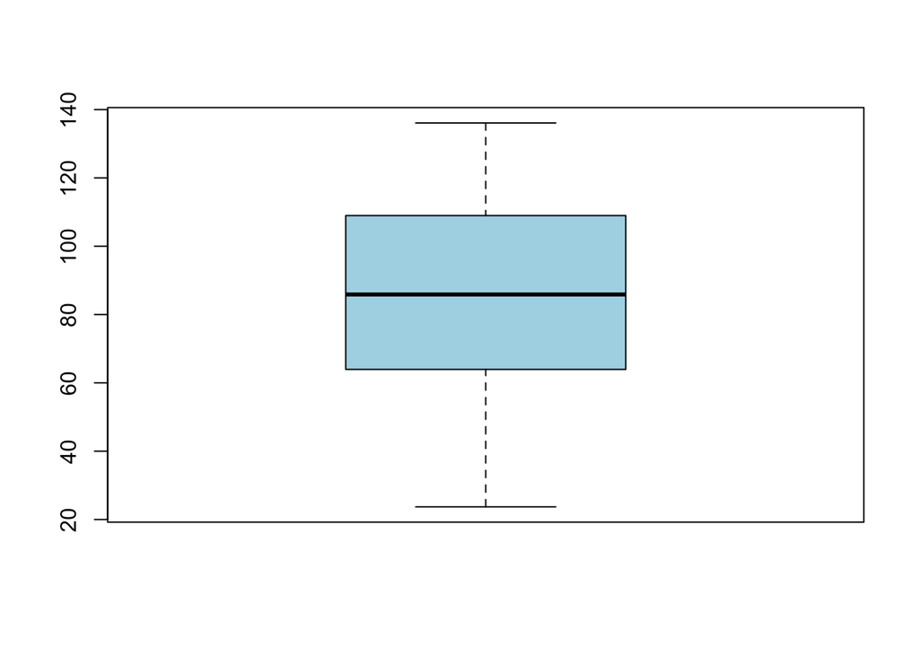

```r
boxplot(arrivals.ts, col = "lightblue")
```

##### From the boxplot it appears that the data is normally distributed as there seems to be no significant skew. 50% of arrivals in Australia from the US are betweeen 63.95(Q1) and 108.98(Q3). Only 25% of arrivals are below 63.95 and 25% are above 108.98. There are also no outliers.

### Decomposition

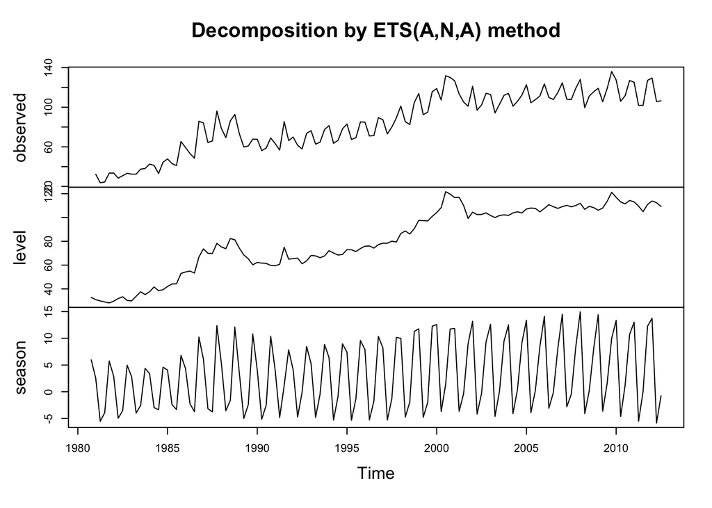

```r
ets_forecast <- ets(arrivals.ts)
plot(ets_forecast)
```

##### Yes, the time series is seasonal. The decomposition is additive.

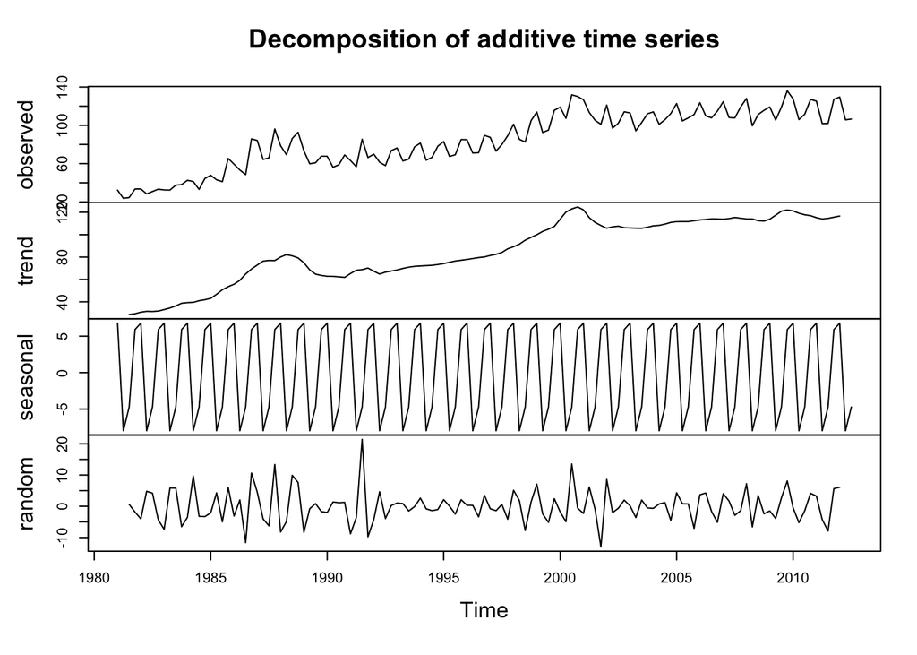

```r
decomp_arrivals <- decompose(arrivals.ts)
plot(decomp_arrivals)
```

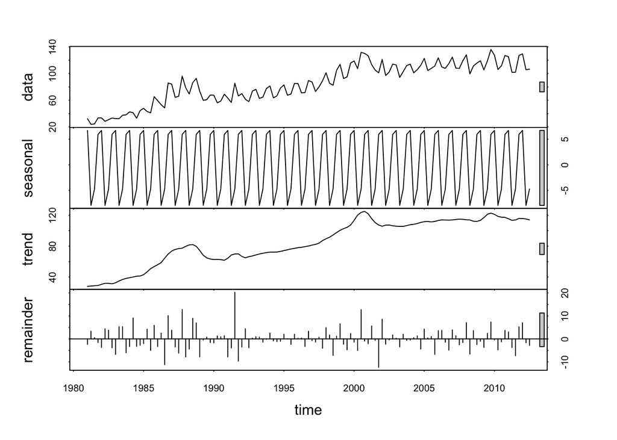

```r
stl_decomp <- stl(arrivals.ts, s.window = "periodic")
plot(stl_decomp)
```